# Feature Selection

Christoph Völtzke

2023

## Packages

```r
# Processing
library(readr) # read data
library(tidyverse) # data manipulation
# Feature Selection and Imbalance
library(ggcorrplot) # features correlation
library(caret) # find correlation function
library(Boruta) # Boruta feature selection
library(infotheo) # Mutual information feature importance
```

# Information

- In this document first the combined data set from pre-rpocessing is further cleaned for the purposes of this study.
- Then data is plit to only perform any analyses on the training data, but not on the test data.
- Next feature selection is performed. All steps are explained below in detail.
  - Included are: Correlation checks, Mutual Information criteria, Boruta feature selection and expert knowledge.
- Plots are generated used in the report and dfs are created and saved which are used for model training

## Load data sets which need to be balanced

```r
source("Functions/data_split.R")
```

## Original data

```r
full_data <- read_csv("~/GitHub/Sweet_Dreams_Ahead_Machine_Learning_Models_for_Nocturnal_Hypoglycemia_Prediction_in_Type_2_Diabetes/Processing_and_Extraction/Data_processed/full_data.csv")
```

## Cleaning of full data sets for different tasks (Hyper/Hypo) w/o Outcomes

Only relevant variables are selected, variables are renamed to make them easier to understand for the reader, Two data conditions are subsetted. Full data condition and Lifestyle condition

```r
# cleaning of unnecessary vars
data <- full_data %>%
  mutate(wday = factor(wday),
         weekend = factor(weekend)) %>%
  select(-periods,-DM_type,-Night_time_mean_glucose_ti,-Night_time_sd_glucose_ti,-Night_time_min_glucose_ti,-Night_time_max_glucose_ti,-Night_late_mean_glucose,-Night_late_sd_glucose,-Night_late_min_glucose,-Night_late_max_glucose,-Night_late_Hyper_events,-Night_late_Hypo_events,-Night_early_Night_class_hyper_out,-Night_late_Night_class_hyper_out,-Night_class_hyper_out,-Day_Night_class_hypo_out,-Day_Night_class_hyper_out,-Day_Night_class_hyper_30) %>%
  na.omit()

# cleaning for full night
full_data <- data %>%
  mutate(Night_class_hyper_30 = factor(Night_class_hyper_30),
          Night_class_hypo_out = factor(Night_class_hypo_out)) %>%
  select(-Night_early_mean_glucose,-Night_early_sd_glucose,-Night_early_min_glucose,-Night_early_max_glucose,-Night_early_Hyper_events,-Night_early_Hypo_events,-Night_early_Night_class_hypo_out,-Night_late_Night_class_hypo_out,-Night_early_Night_class_hyper_30,-Night_late_Night_class_hyper_30) %>%
  select(Night_class_hypo_out,Night_class_hyper_30,patient,hour_0_1_before_mean_glucose_ti:slope_day,COB,Sum_carbs,Sum_calories,Sum_Fat,Num_Meals,Last_meal,AOB,Sum_steps,wday,weekend,Geslacht:dosA10BB)

# Features are renamed to make them easier to understand in the study as some names will be depicted in one of the tables
full_data <- full_data %>%
  rename(mean_0_1 = hour_0_1_before_mean_glucose_ti, mean_1_2 =hours_1_2_before_mean_glucose_ti,mean_2_3 =hours_2_3_before_mean_glucose_ti,
         mean_3_4 =hours_3_4_before_mean_glucose_ti,mean_4_5 =hours_4_5_before_mean_glucose_ti,mean_5_6 =hours_5_6_before_mean_glucose_ti,mean_6pl =hours_7_plus_mean_glucose_ti,
         sd_0_1 = hour_0_1_before_sd_glucose_ti, sd_1_2 =hours_1_2_before_sd_glucose_ti,sd_2_3 =hours_2_3_before_sd_glucose_ti,
         sd_3_4 =hours_3_4_before_sd_glucose_ti,sd_4_5 =hours_4_5_before_sd_glucose_ti,sd_5_6 =hours_5_6_before_sd_glucose_ti,sd_6pl =hours_7_plus_sd_glucose_ti,
         min_0_1 = hour_0_1_before_min_glucose_ti, min_1_2 =hours_1_2_before_min_glucose_ti,min_2_3 =hours_2_3_before_min_glucose_ti,
         min_3_4 =hours_3_4_before_min_glucose_ti,min_4_5 =hours_4_5_before_min_glucose_ti,min_5_6 =hours_5_6_before_min_glucose_ti,min_6pl =hours_7_plus_min_glucose_ti,
         max_0_1 = hour_0_1_before_max_glucose_ti, max_1_2 =hours_1_2_before_max_glucose_ti,max_2_3 =hours_2_3_before_max_glucose_ti,
         max_3_4 =hours_3_4_before_max_glucose_ti,max_4_5 =hours_4_5_before_max_glucose_ti,max_5_6 =hours_5_6_before_max_glucose_ti,max_6pl =hours_7_plus_max_glucose_ti,
         mean_day = Day_mean_glucose, sd_day = Day_sd_glucose, min_day = Day_min_glucose,max_day = Day_max_glucose,Hyper_n = Day_Hyper_events, Hypo_n = Day_Hypo_events,
         hyper_Ind = hyper_index, hypo_Ind = hypo_index, tir_70_180 = in_range_70_180, tir_63_140 = in_range_63_140, slope_0_1 = hour_0_1_before_slope_day, slope_1_2 = hours_1_2_before_slope_day, Steps = Sum_steps, Carbs = Sum_carbs, Calories = Sum_calories,Fat= Sum_Fat, Height = Lengte_poli1, Weight = Gewicht_poli1, Gender = Geslacht, Age = Leeftijd_poli1, T2D_Dur = Diabetes_Length, T2D_Start = Leeftijd_aanvangDM2, HbA1c = SerumHbA1c_1, insulin = insulin_bin, fast_ins = atcA10AB, dos_fast = dosA10AB, int_long = atcA10AD, dos_int_long = dosA10AD, long_ins = atcA10AE, dos_long = dosA10AE, SU_der = atcA10BB, dos_SU = dosA10BB)


# LIFESTYLE DATA
full_data_life_plus <- full_data %>% select(Night_class_hypo_out,Night_class_hyper_30,patient,
                                            COB:Last_meal, AOB:Steps,wday:dos_SU)

#write.csv(full_data,"Data/Full_Data/full_data.csv", row.names = FALSE)
```

## Data set preparation - Selection of Outcome variable

```r
full_data <- full_data %>%
  mutate(Night_class_hypo_out = as.factor(Night_class_hypo_out),
         Night_class_hyper_30 = as.factor(Night_class_hyper_30)) %>%
  select(-Night_class_hyper_30,-patient)

full_data_life_plus <- full_data_life_plus %>%
  mutate(Night_class_hypo_out = as.factor(Night_class_hypo_out),
         Night_class_hyper_30 = as.factor(Night_class_hyper_30)) %>%
  select(-Night_class_hyper_30,-patient)
```

## Data split train/test

```r
full_data_split <- data_split(full_data,train_size= 0.75, seed = 123)
full_data_train <- full_data_split[[1]]
full_data_test <- full_data_split[[2]]

full_data_life_plus_split <- data_split(full_data_life_plus,train_size= 0.75, seed = 123)
full_data_life_plus_train <- full_data_life_plus_split[[1]]
full_data_life_plus_test <- full_data_life_plus_split[[2]]
```

# Steps - Feature selection

Feature selection is performed in multiple steps.

1. Correlations were checked, but only as an optional step to see how data is distributed
2. Mutual Information is calculated based on similarities of features entropies with the outcome variable
3. Boruta feature selection is performed for both data conditions, the Full data condition and the Lifestyle condition
4. Features are selected based on both approaches.
5. Expert knowledge is taken into account and additional features are selected for the analyses.

### Correlation approach - OPTIONAL

This is just to get an impression of the data.

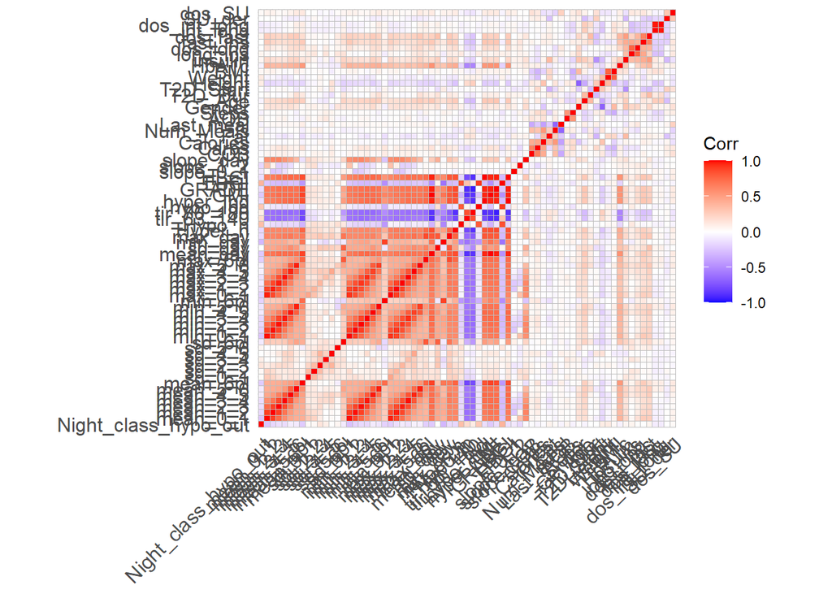

```r
full_data_train_nums <- full_data_train %>%
  mutate(Night_class_hypo_out = as.numeric(Night_class_hypo_out)) %>%
  select_if(is.numeric)
cor_matrix <- data.frame(cor(full_data_train_nums))

ggcorrplot(cor_matrix)
```

```r
del_vars <- findCorrelation(cor(cor_matrix), cutoff=0.995)
full_data_train_del <- full_data_train[,del_vars] # to see which vars to delete
full_data_train_col <- full_data_train[,-del_vars]
colnames(full_data_train_del)
```

```
##  [1] "HBGI"      "hyper_Ind" "GRADE"     "mean_day"  "min_4_5"   "mean_3_4"
##  [7] "mean_5_6"  "mean_2_3"  "max_1_2"   "mean_1_2"  "mean_0_1"  "fast_ins"
```

```r
ncol(full_data_train_col)
```

```
## [1] 61
```

```r
# Very high/Low correlations are detected for the CGM features - However, this is to be expected due to the same data origin for feature extration
```

```r
cor_matrix_dv <- cor_matrix %>% filter(cor_matrix$Night_class_hypo_out <= -0.5 | cor_matrix$Night_class_hypo_out >= 0.5)
cor_matrix_dv
```

```
##                      Night_class_hypo_out   mean_0_1   mean_1_2  mean_2_3
## Night_class_hypo_out                    1 -0.2468591 -0.1733234 -0.137744
##                        mean_3_4    mean_4_5    mean_5_6   mean_6pl     sd_0_1
## Night_class_hypo_out -0.1453978 -0.08404654 -0.08756489 -0.2192139 0.03367274
##                          sd_1_2    sd_2_3     sd_3_4     sd_4_5     sd_5_6
## Night_class_hypo_out 0.04037027 0.1372531 0.08963487 0.00360119 0.05243419
##                           sd_6pl    min_0_1    min_1_2    min_2_3    min_3_4
## Night_class_hypo_out -0.09271161 -0.2585558 -0.1861614 -0.1628456 -0.1657532
##                          min_4_5    min_5_6    min_6pl   max_0_1    max_1_2
## Night_class_hypo_out -0.08991712 -0.1050649 -0.1948245 -0.211965 -0.1436362
##                         max_2_3   max_3_4     max_4_5     max_5_6    max_6pl
## Night_class_hypo_out -0.0923284 -0.123468 -0.06498487 -0.07042897 -0.2054673
##                       mean_day      sd_day    min_day    max_day    Hyper_n
## Night_class_hypo_out -0.226027 0.001770546 -0.3101003 -0.1631203 -0.1738326
##                         Hypo_n tir_63_140 tir_70_180  hypo_Ind  hyper_Ind
## Night_class_hypo_out 0.3411632  0.1894531 0.09610079 0.2925526 -0.1374126
##                             GMI      GRADE      LBGI       HBGI   slope_0_1
## Night_class_hypo_out -0.2261272 -0.1497352 0.3905704 -0.1431068 -0.09618077
##                       slope_1_2   slope_day         COB       Carbs    Calories
## Night_class_hypo_out -0.1728225 -0.03396408 -0.02418628 -0.05013866 -0.02387719
##                            Fat  Num_Meals   Last_meal        AOB       Steps
## Night_class_hypo_out 0.0729468 0.03203649 -0.04615708 0.05746676 -0.05884553
##                          Gender         Age      T2D_Dur   T2D_Start     Height
## Night_class_hypo_out 0.02422907 -0.04784589 -0.004552603 0.004119618 0.09651962
##                         Weight        BMI       HbA1c    insulin   long_ins
## Night_class_hypo_out 0.1114402 0.04331595 -0.06486763 0.04599986 0.06312614
##                        dos_long    fast_ins  dos_fast    int_long dos_int_long
## Night_class_hypo_out 0.01484222 0.001888556 0.0620533 -0.08466572  -0.08797856
##                            SU_der     dos_SU
## Night_class_hypo_out 0.0006296654 0.03153161
```

```r
# No variable has a correlation of 0.5/-0.5 or higher/lower with the DV
```

# Mutual information criteria

## Features based on Mutual Information are compared with the outcome variable

A Threshold is applied with 0.01 for Full data condition and 0.005 for Lifestyle condition

```r
options(scipen = 999)
all <- infotheo::discretize(full_data_train)
mut_inf <- mutinformation(all,method= "emp")
mut_inf <- as.data.frame(mut_inf[,1])
mut_inf <- rownames_to_column(mut_inf, var = "feature")
mut_inf <- mut_inf %>%
  filter(feature != "Night_class_hypo_out") %>%
  rename(importance = "mut_inf[, 1]") %>%
  arrange(desc(importance)) %>%
  filter(importance >= 0.01)
print(mut_inf)
```

```
##       feature importance
## 1    hypo_Ind 0.08717653
## 2     min_day 0.08204313
## 3        LBGI 0.08009280
## 4      Hypo_n 0.06674338
## 5     max_6pl 0.05382713
## 6    mean_0_1 0.05251379
## 7         GMI 0.05130710
## 8    mean_day 0.05124863
## 9    mean_6pl 0.05022811
## 10    min_6pl 0.04829738
## 11    min_0_1 0.04730316
## 12    max_0_1 0.04706128
## 13    Hyper_n 0.03484570
## 14        BMI 0.02928449
```

[output cut: 30 more lines]

Due to lower similarity with non CGM features a lower treshold is tested for only the variables in the Lifestyle condition. *NOTE* Values stay the same to the approach before as the mutual information approach is independent of any model and always produces the same estimates no matter how many variables are included.

```r
options(scipen = 999)
life <- infotheo::discretize(full_data_life_plus_train)
mut_inf_life <- mutinformation(life,method= "emp")
mut_inf_life <- as.data.frame(mut_inf_life[,1])
mut_inf_life <- rownames_to_column(mut_inf_life, var = "feature")
mut_inf_life <- mut_inf_life %>%
  filter(feature != "Night_class_hypo_out") %>%
  rename(importance = "mut_inf_life[, 1]") %>%
  arrange(desc(importance)) %>%
  filter(importance >= 0.005)
print(mut_inf_life)
```

```
##      feature  importance
## 1        BMI 0.029284486
## 2      HbA1c 0.025191415
## 3     Weight 0.023274848
## 4      Steps 0.021244346
## 5     Height 0.020937652
## 6    T2D_Dur 0.019636253
## 7        AOB 0.017902744
## 8        Age 0.015802704
## 9   Calories 0.014117499
## 10 T2D_Start 0.012496245
## 11       Fat 0.009632974
## 12       COB 0.009140614
## 13 Num_Meals 0.007336847
## 14  dos_long 0.007323444
## 15      wday 0.006967453
## 16     Carbs 0.006807550
## 17 Last_meal 0.006467564
```

## For Full data condition

Boruta feature selection for full data condition. This is repeated for Lifestyle as importance scores change due to inclusion of certain variables.

```r
set.seed(123)
boruta_output_full <- Boruta(Night_class_hypo_out ~ ., data=full_data_train, doTrace=0)
boruta_signif_full <- getSelectedAttributes(boruta_output_full, withTentative = TRUE)
roughFixMod <- TentativeRoughFix(boruta_output_full)
boruta_signif <- getSelectedAttributes(roughFixMod)
```

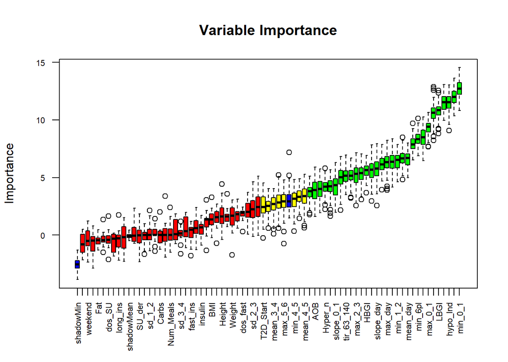

```r
# This plot shows the distribution of selected, tentative and rejected variables for the full data condition
imps_full <- attStats(boruta_output_full)
imps_full = imps_full[imps_full$decision != 'Rejected', c('meanImp', 'decision')]
plot(boruta_output_full, cex.axis=.7, las=2, xlab="", main="Variable Importance")
```

## For Lifestyle condition

Boruta feature selection with lifestyle condition.

```r
boruta_output_life <- Boruta(Night_class_hypo_out ~ ., data=full_data_life_plus_train, doTrace=0)
boruta_signif_life <- getSelectedAttributes(boruta_output_life, withTentative = TRUE)
roughFixMod <- TentativeRoughFix(boruta_output_life)
boruta_signif <- getSelectedAttributes(roughFixMod)
```

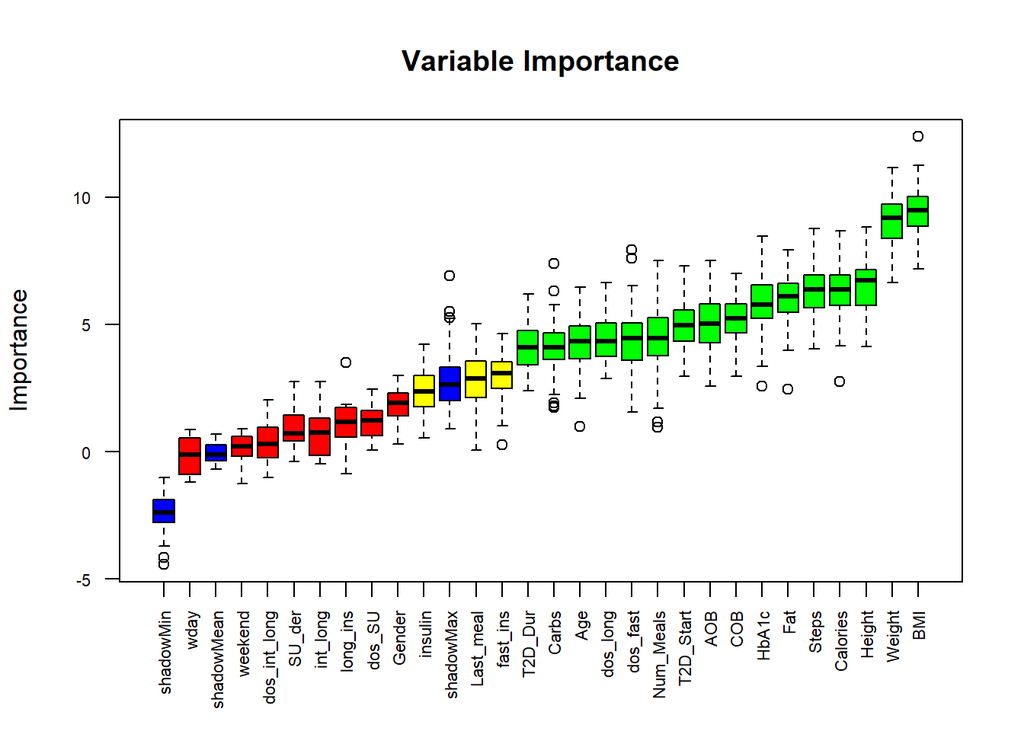

```r
# This plot shows the distribution of selected, tentative and rejected variables for the Lifestyle condition
imps_life <- attStats(boruta_output_life)
imps_life = imps_life[imps_life$decision != 'Rejected', c('meanImp', 'decision')]
plot(boruta_output_life, cex.axis=.7, las=2, xlab="", main="Variable Importance")
```

## Feature Importance plot based on Boruta feature selection

This plot shows the mean Importance of variables over multiple iterations based on mean decrease accuracy as part of an RF approach.

This plot is used in the report to emphasize which variables performed best.

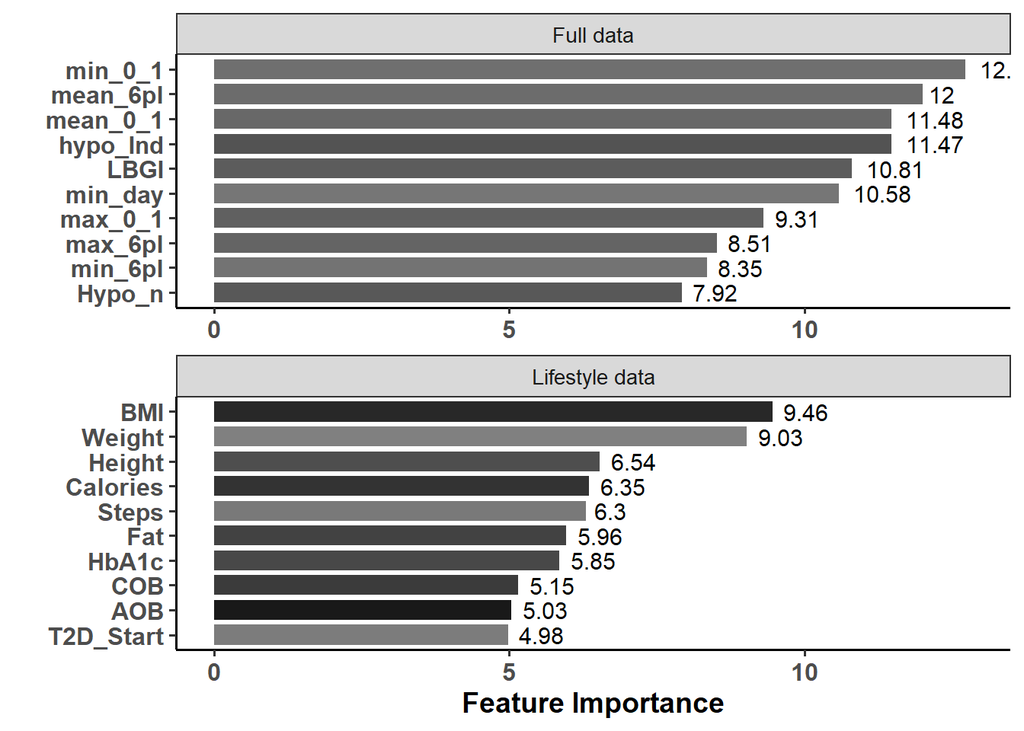

```r
varimp_full <- imps_full[order(-imps_full$meanImp), ] %>% select(-decision) %>% rownames_to_column("feature") %>% rename(importance = meanImp) %>% mutate(Condition = "Full data")
varimp_life<- imps_life[order(-imps_life$meanImp), ] %>% select(-decision) %>% rownames_to_column("feature") %>% rename(importance = meanImp) %>% mutate(Condition = "Lifestyle data")

all_top_features <- rbind(varimp_full[1:10,],varimp_life[1:10,])

all_top <- ggplot(data = all_top_features,
       aes(x = reorder(feature, importance), y = importance, fill = feature)) +
  facet_wrap(~ Condition,scales="free",ncol=1) +
  geom_bar(stat="identity", width = 0.8) + scale_fill_grey(start = 0.1, end = 0.5) +
  geom_text(aes(label = round(importance, 2)), color="black", size=4, hjust = -0.25, position = position_dodge(width = 0.5),inherit.aes = TRUE) +
  theme_bw(base_size = 12) + theme(legend.position = "none") + scale_x_discrete(guide = guide_axis(n.dodge=1)) + theme_bw(base_size = 13) +
  theme(legend.position="",
        panel.border = element_blank(),  # remove panel borders
        panel.grid.major = element_blank(),  # remove major grid lines
        panel.grid.minor = element_blank(),  # remove minor grid lines
        axis.line = element_line(),  # set axis lines to bold
        axis.text = element_text(size = 12, face = "bold"),  # set axis text to bold
        axis.title = element_text(size = 14, face = "bold"),
        plot.background = element_blank(),  # remove plot background
        panel.background = element_blank()) +
  coord_flip() +
  ylim(0, max(all_top_features$importance) * 1.01) + labs(y = "Feature Importance", x = "")
print(all_top)
```

For Supplementary Material also the 25 best variables based on MI overall

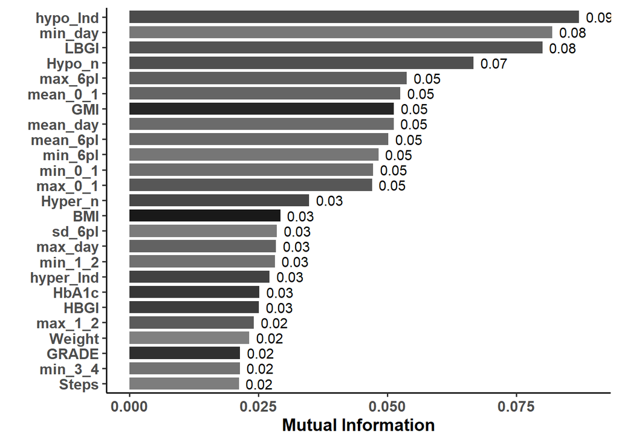

```r
all_top_features <- mut_inf[1:25,]

all_top <- ggplot(data = all_top_features,
       aes(x = reorder(feature, importance), y = importance, fill = feature)) +
  geom_bar(stat="identity", width = 0.8) + scale_fill_grey(start = 0.1, end = 0.5) +
  geom_text(aes(label = round(importance, 2)), color="black", size=4, hjust = -0.25, position = position_dodge(width = 0.5),inherit.aes = TRUE) +
  theme_bw(base_size = 12) + theme(legend.position = "none") + scale_x_discrete(guide = guide_axis(n.dodge=1)) + theme_bw(base_size = 13) +
  theme(legend.position="",
        panel.border = element_blank(),  # remove panel borders
        panel.grid.major = element_blank(),  # remove major grid lines
        panel.grid.minor = element_blank(),  # remove minor grid lines
        axis.line = element_line(),  # set axis lines to bold
        axis.text = element_text(size = 12, face = "bold"),  # set axis text to bold
        axis.title = element_text(size = 14, face = "bold"),
        plot.background = element_blank(),  # remove plot background
        panel.background = element_blank()) +
  coord_flip() +
  ylim(0, max(all_top_features$importance) * 1.02) + labs(y = "Mutual Information", x = "")
print(all_top)
```

## Extract common important features across approaches

```r
# Find the common features selected by both methods
missing_bor <- left_join(varimp_full, mut_inf, by="feature")
missing_bor <- missing_bor[is.na(missing_bor$importance.y), ]

missing_mi <- left_join(mut_inf, varimp_full,by="feature")
missing_mi <- missing_mi[is.na(missing_mi$importance.y), ]

common_vars <- intersect(varimp_full$feature,mut_inf$feature)
common_vars
```

```
##  [1] "min_0_1"    "mean_6pl"   "mean_0_1"   "hypo_Ind"   "LBGI"
##  [6] "min_day"    "max_0_1"    "max_6pl"    "min_6pl"    "Hypo_n"
## [11] "GMI"        "mean_day"   "min_1_2"    "mean_2_3"   "max_day"
## [16] "hyper_Ind"  "min_2_3"    "HBGI"       "max_2_3"    "GRADE"
## [21] "tir_63_140" "mean_1_2"   "max_1_2"    "Hyper_n"    "sd_6pl"
## [26] "AOB"        "mean_4_5"   "min_3_4"    "min_4_5"    "mean_5_6"
## [31] "mean_3_4"   "T2D_Start"  "max_3_4"
```

```r
missing_bor$feature
```

```
## [1] "slope_day"  "sd_day"     "slope_0_1"  "tir_70_180" "max_5_6"
```

```r
missing_mi$feature
```

```
##  [1] "BMI"       "HbA1c"     "Weight"    "Steps"     "Height"    "T2D_Dur"
##  [7] "slope_1_2" "Age"       "max_4_5"   "Calories"  "min_5_6"
```

```r
# Variables selected based on Expert knowledge to be included
extra_expert_full <- c("slope_0_1","tir_70_180","BMI","HbA1c","Weight","Height","T2D_Dur","Age")
```

### Lifestyle Condition

Same for the Lifestyle condition. As the results of Boruta differ this has to be done again. The overlapping features are directly included and some variables are further included based on Expert knowledge.

```r
# Find the common features selected by both methods
missing_bor_life <- left_join(varimp_life, mut_inf_life, by="feature")
missing_bor_life <- missing_bor_life[is.na(missing_bor_life$importance.y), ]

missing_mi_life <- left_join(mut_inf_life, varimp_life,by="feature")
missing_mi_life <- missing_mi_life[is.na(missing_mi_life$importance.y), ]

common_vars_life <- intersect(varimp_life$feature,mut_inf_life$feature)
common_vars_life
```

```
##  [1] "BMI"       "Weight"    "Height"    "Calories"  "Steps"     "Fat"
##  [7] "HbA1c"     "COB"       "AOB"       "T2D_Start" "Num_Meals" "dos_long"
## [13] "Age"       "Carbs"     "T2D_Dur"   "Last_meal"
```

```r
missing_bor_life$feature
```

```
## [1] "dos_fast" "fast_ins" "insulin"
```

```r
missing_mi_life$feature
```

```
## [1] "wday"
```

```r
#  Variables selected based on Expert knowledge to be included
extra_expert_life <- c("dos_fast","fast_ins")
```

## Final Selection both data conditions

Combing the data sets and seeing how many features are selected

```r
# Combining selected and expert knowledge for both data conditions

full_data_sel <- full_data %>% select(Night_class_hypo_out,common_vars,extra_expert_full)

full_data_life_plus_sel <- full_data_life_plus %>% select(Night_class_hypo_out,common_vars_life,extra_expert_life)
colnames(full_data_sel) # -1 for outcome variable = Features
```

```
##  [1] "Night_class_hypo_out" "min_0_1"              "mean_6pl"
##  [4] "mean_0_1"             "hypo_Ind"             "LBGI"
##  [7] "min_day"              "max_0_1"              "max_6pl"
## [10] "min_6pl"              "Hypo_n"               "GMI"
## [13] "mean_day"             "min_1_2"              "mean_2_3"
## [16] "max_day"              "hyper_Ind"            "min_2_3"
## [19] "HBGI"                 "max_2_3"              "GRADE"
## [22] "tir_63_140"           "mean_1_2"             "max_1_2"
## [25] "Hyper_n"              "sd_6pl"               "AOB"
## [28] "mean_4_5"             "min_3_4"              "min_4_5"
## [31] "mean_5_6"             "mean_3_4"             "T2D_Start"
## [34] "max_3_4"              "slope_0_1"            "tir_70_180"
## [37] "BMI"                  "HbA1c"                "Weight"
## [40] "Height"               "T2D_Dur"              "Age"
```

```r
colnames(full_data_life_plus_sel) # -1 for outcome variable = Features
```

```
##  [1] "Night_class_hypo_out" "BMI"                  "Weight"
##  [4] "Height"               "Calories"             "Steps"
##  [7] "Fat"                  "HbA1c"                "COB"
## [10] "AOB"                  "T2D_Start"            "Num_Meals"
## [13] "dos_long"             "Age"                  "Carbs"
## [16] "T2D_Dur"              "Last_meal"            "dos_fast"
## [19] "fast_ins"
```

## Saved data and feature selection process

Data is saved for further analyses.

```r
#write.csv(full_data_sel,"Data/Full_data/full_data_sel.csv", row.names = FALSE)
#write.csv(full_data_life_plus_sel,"Data/Full_data/full_data_life_plus_sel.csv", row.names = FALSE)

#feature_selection <- list(boruta_full= boruta_output_full, boruta_sig_full = boruta_signif_full, Vari_imp_full = varimp_full,boruta_life= boruta_output_life, boruta_sig_life = boruta_signif_life, Vari_imp_life = varimp_life)
#saveRDS(feature_selection, file = "Data/Feature_Selection/feature_selection.RData")
```